# A Study on the Aggregation of Linear Reservoirs

**The story**: Linear reservoirs form the basis building block of most conceptual rainfall-runoff models. They can be combined or extended in a non-linear fashion to account for many complex behaviors. Furthermore, on the grand scale of things they can be seen as approximations to the Saint-Venant equations and are thus even physically justified (somehow, also see: Klemes (1982) and Szilágyi and Szöllösi-Nagy (2010)).

For now let us assume that we study a hydrological system that consists of multiple linear reservoirs. The response of each reservoir is defined by a single constant $tab$ and the overall runoff of the system (which is also the only part that is measurable) is given by the sum of the individual runoffs.

We try to answer the following question by use of simulation:

> Is it possible to use arithmetic mean of the reservoir constants to get a lumped reservoir which represents the behavior or response of the individual (“fine scale”) reservoirs

**A Little bit of Hydrology**

In their search for effective parameters hydrologist usually revert back to the concept of hydrological response units (*HRUs*). The idea is to search for regions which are spatially homogenous and lump them together. Afterwards the effective parameters are usually estimated by optimization.

A more modern approach, called multiscale-parameter regionalization (MPR), suggests to first estimate the parameters at the finest possible scale and aggregate the parameters themselves afterwards. To make the fine-scale estimation possible it is assumed that the model parameters can be explicitly defined by a functional relationship with landscape properties.

My PHD is devoted to these functional relationships, but in this document we shall focus on the properties of the aggregation.

# The Setup

Let us start with the experimental setup by defining a functional that returns a parameterized linear reservoir as a function of $tab$.

```r
spawn_linres <- function(tab) {
    q0 <- 0
    s <- 0
    linres <- function(qin) {
      qin - (tab*qin-s)*(1.-exp(-1/tab))
      q_out <- qin - (tab*qin-s)*(1.-exp(-1/tab))
      s <<- s + qin -q_out
      return(q_out)
    }
    return(linres)
}
```

The following figure uses the functional to exemplify how different reservoirs behave with respect to different values of $tab$ (in relation to a unit input of 20)

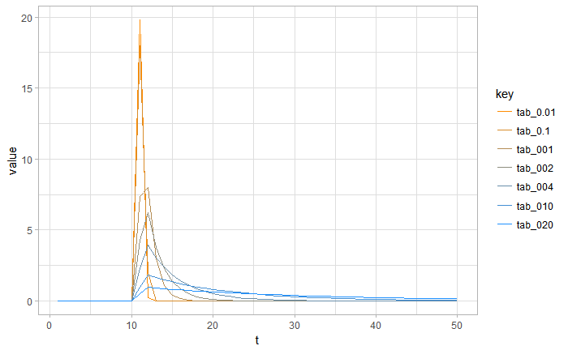

We can see that **small** values of $tab$ lead to responsive behavior with fast depletion (orange lines), while **large** values of $tab$ lead to a dampened response with long memory (slow depletion, blue lines). Ok, now lets do the analysis.

# The Simple Case: From 2 to 1

First, let us say that we have two linear reservoirs $n=2$ which ought to be represented by a single one. To keep things simple let us also assume that both have the same input. We can then generate a sample of different $tab$ values and check how good the different means of the $tab$ represent the overall behavior of the system. We will use the venerable Nash-Sutcliffe Efficiency, short $NSE$ (i.e. the $R^2$ of the runoff) as a distance measure/objective function.

## Symmetry

Let us start by plotting an exemplary hydrograph from the generated samples. The overall (i.e. *real*) response of the system is depicted in blue, the individual fine-scale reservoirs in violet-tones and the response from the aggregated/averaged reservoir is shown in orange:

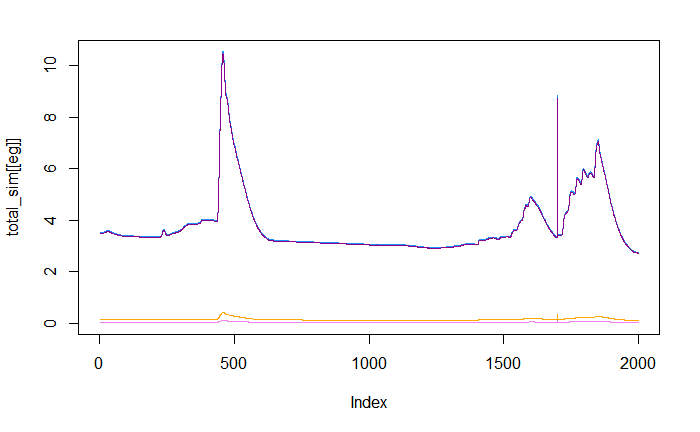

Ok! Now we can make a plot which shows the $NSE$ values of the aggregated reservoir in dependence of the sampled “fine-scaled” $tab_i$ values. We can see that the best (highest) $NSE$ values are on the 1:1 line. This makes sense, because there the relation $tab_1 = tab_2$holds (and the inputs are the same). One can also see that the behavior is symmetric with regard to the line. This is also an effect of the equal inputs, since $tab_1 + tab_2 \equiv tab_2 + tab_1$. We can also observe that the aggregation works better for larger $tab$ values. This is mainly because of the behavior of the linear reservoirs (see: first section): More dampened functions exhibit smaller errors. Thus, a better $NSE$ value can be expected.

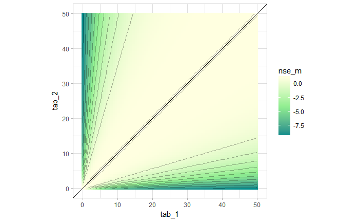

The behavior and sensitivity of the results depends on the basin properties and on the chosen objective function. An example is given in the following figure, which shows that the sum of absolute relative errors ($e_rel$) is less forgiving than the $NSE$:

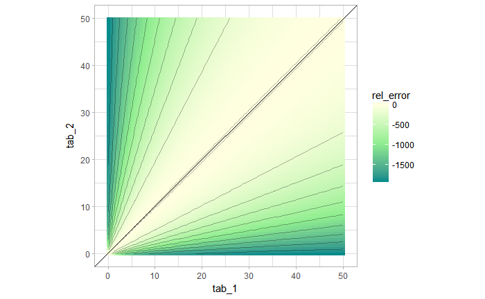

## The Asymmetric Case

How do the result change if the input for the reservoirs is different? **Not much!** The 1:1 line does not make a symmetry anymore, but higher $tab$ values are still easier to aggregate (whatever the means). Here is an example which uses the same input as above for one of the fine scaled reservoirs, but a different input for the other one.

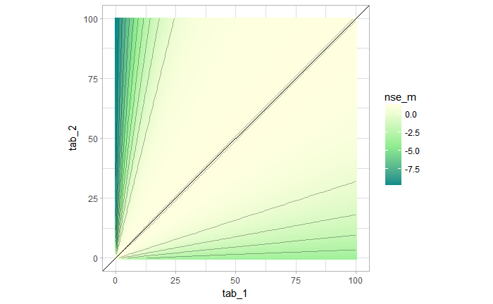

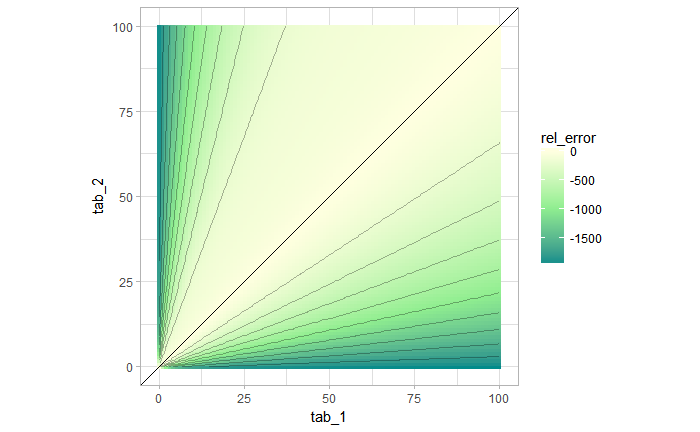

We can note two things. (a) With regard to the $NSE$: the $tab_2$ values are now more insensitive, while the $tab_1$ values still exhibit the same pattern. And (b) The sensitivity pattern of $e_rel$ is however inverted! The aggregation is more sensitive to changes of $tab_2$, than to changes of $tab_1$.

### Summary

In summary we can say that perfect aggregation with the arithmetic mean is possible in the trivial case, where $tab_1 = tab_2$ (independent of the input). For all other cases the mean is an imperfect approximation. In general, the quality of the approximations is better (less sensitive) for larger $tab$ values. The quality decline (of the approximation) is dependent on basin properties (in our case the input) and the chosen objective functions. Averaging seems to be more difficult if one is interested in relative measures.

# Higher Dimensions: From 3 to 1

Do these findings hold true in higher dimensions? To answer that question, let us try to aggregate 3 fine-scaled reservoirs next and see what happens.

To do so we will (again) use different inputs, as shown here:

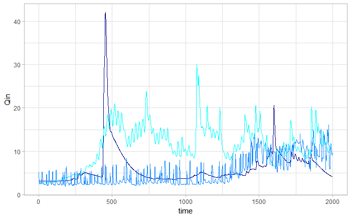

## Glimpses of the Cube

The result now has for dimensions, but We can still think of it as a cube: The different $tab_i$ form the axis and the information of the objective function can be defined with the help of colors.

Here are some views of the cubes for the $NSE$ and the $e_{rel}$ distance measures. Some information gets lost because of the static 3d views. We therefore added the `plotly` code to create them, in case you want to explore the pattern yourself.

$NSE$ cube

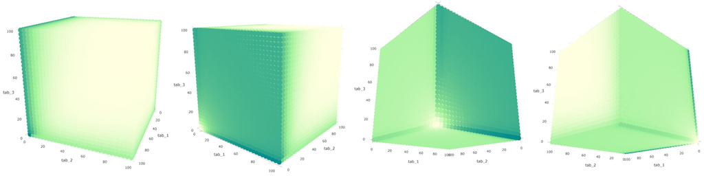

$e_{rel}$ cube

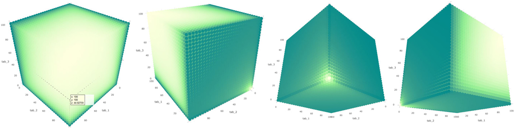

```r
# nse Cube:
plotly::plot_ly(tab3_results,
        x = ~tab_1,
        y = ~tab_2,
        z = ~tab_3,
        color = ~nse_m,
        size = ~le_size,
        sizes = c(0,20),
        colors   = c("darkcyan","lightgreen","lightyellow"))
# rel_error cube:
plotly::plot_ly(tab3_results,
        x = ~tab_1,
        y = ~tab_2,
        z = ~tab_3,
        color = ~rel_error,
        size = ~le_size,
        sizes = c(0,20),
        colors   = c("darkcyan","lightgreen","lightyellow"))
```

## Slice & Dice

The cubes from above give an impression of the overall patter of the objective functions. Now, we will look at them in detail by inspecting different subviews of both cubes:

### Average Dices

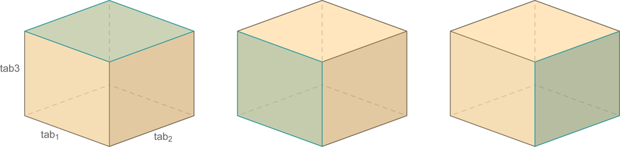

The following plots show the average view for each pixel or a given side. As depicted above one can think of it as looking from one side (marked in green) at the cube and seeing the average samples along the view-axis.

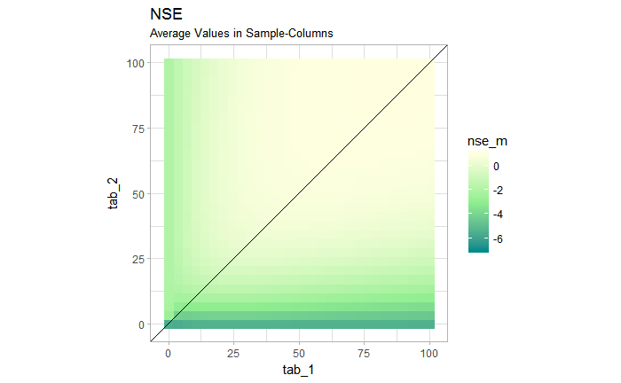

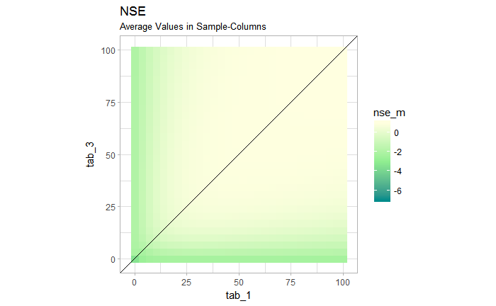

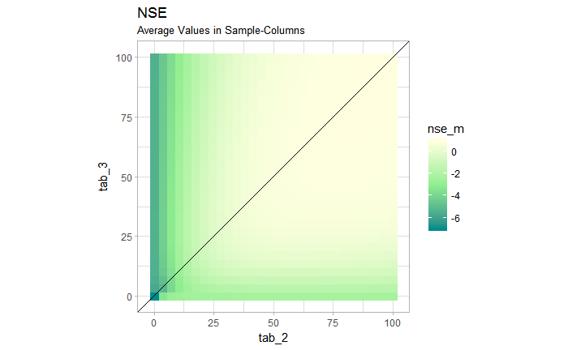

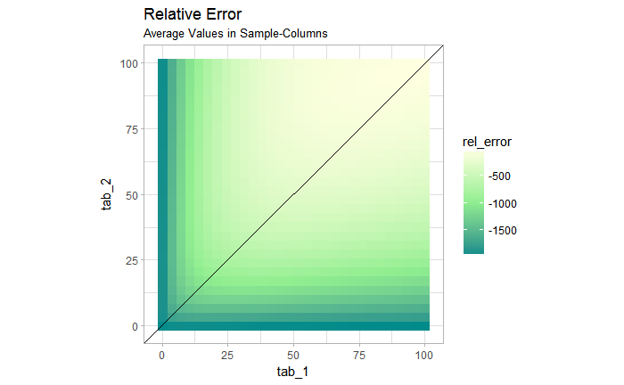

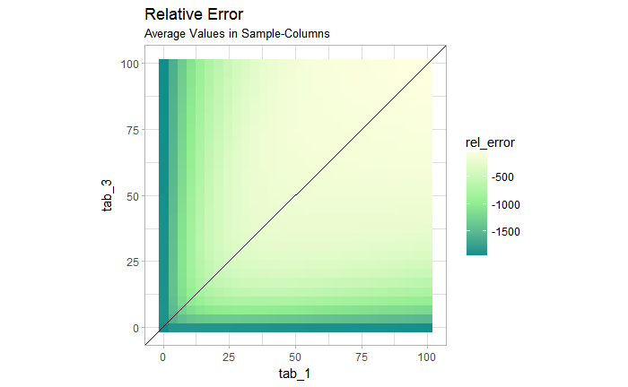

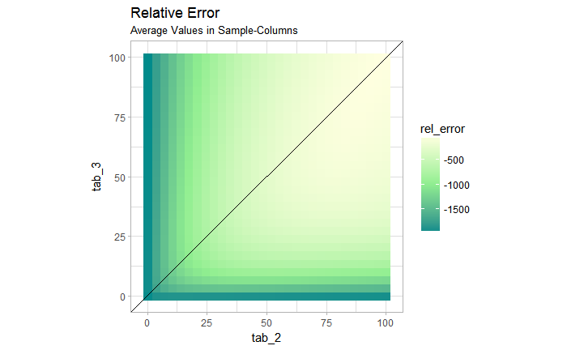

### Horizontal Slices

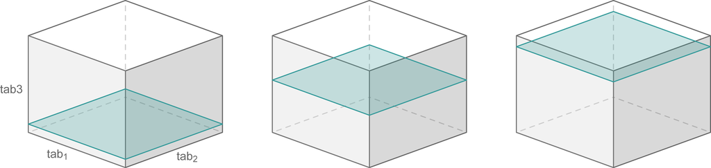

The *horizontal slices* view a plain of the cube by fixing the $tab_{3}$ at one value for each slice. As shown in the figure above, we made three slices, one for low-, one for mid- and one for high-values of $tab_{3}$. In the following we thus have six figures in total (three for the $NSE$ and three for the $e_{rel}$).

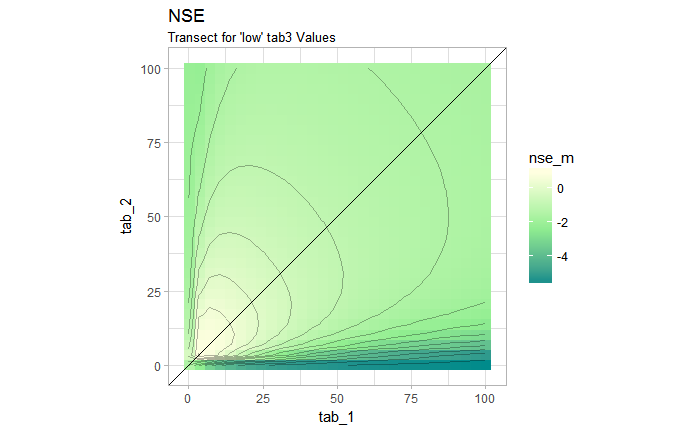

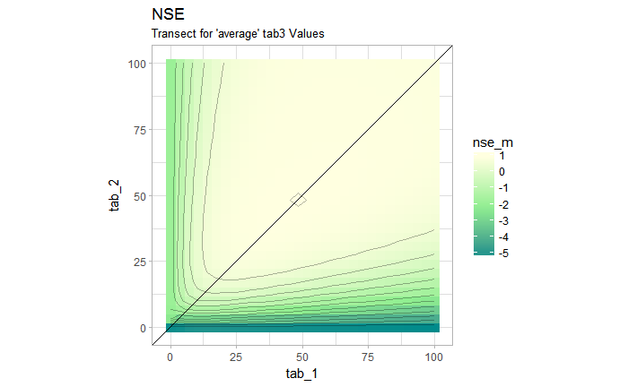

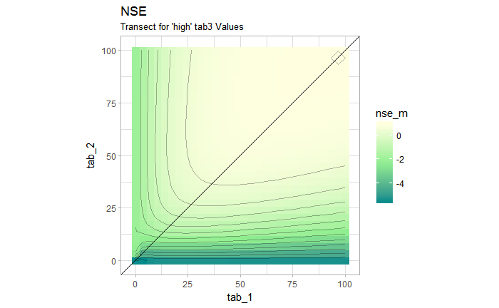

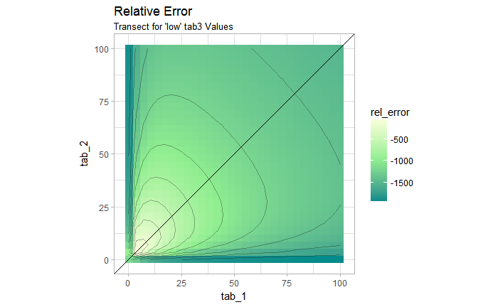

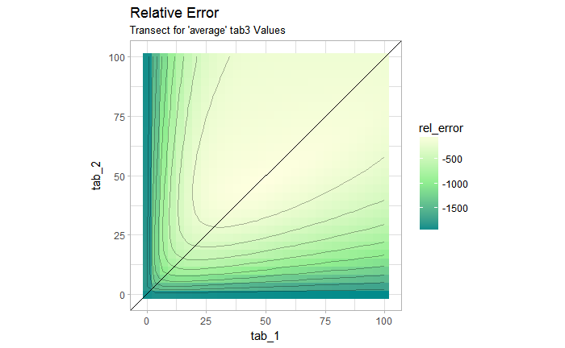

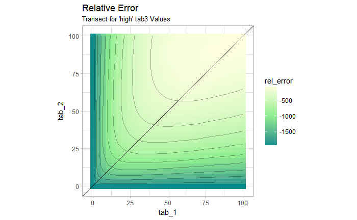

## Summary

In this section we showed the relations between the behavior of three single reservoirs and the behavior that results from aggregating their respective constants $tab_i$. We saw that the trivial case, i.e. the 1:1:1 line (where $tab_1 = tab_2 = tab_3$), results in perfect aggregation (for both, the $NSE$ and the $e_rel$). It can also be seen that higher $tab$ values are associated with better objective functions values (in the averaged views this can be especially well seen).

# Is there a Solution?

Lastly, let us consider the following question:

> Can a single reservoirs is able to represent multiple reservoirs at all?

For this we will optimize the previously aggregated $tab$ value of the single reservoir for each sampled point. We will do this for the asymmetric case of two $tab$ values and the asymmetric case of three $tab$ values.

For each sample point we will use a simple derivative free optimization routine provided by `stats::optimize` (it actually is a `FORTRAN` code, which combines the golden section search and successive parabolic interpolation).

## Asymmetric case with two $tab$ values

In the following are the results for the asymmetric case of two $tab$ values represented by a single reservoir. Note, the asymmetry of values for the $NSE$ and decay away from the 1:1 line.

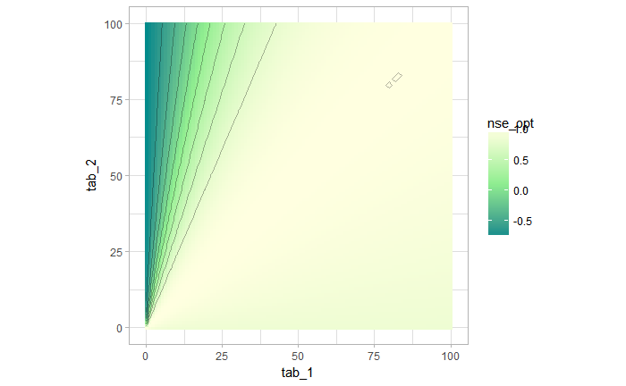

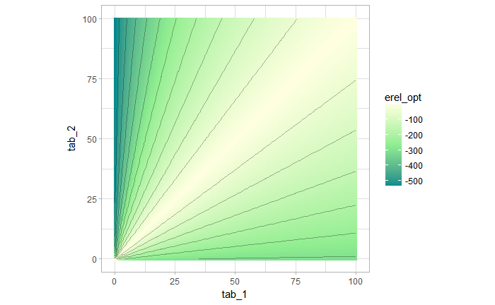

## Asymmetric Case with three $tab$ values

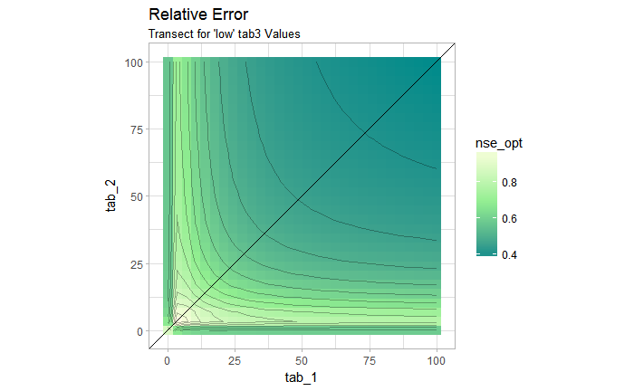

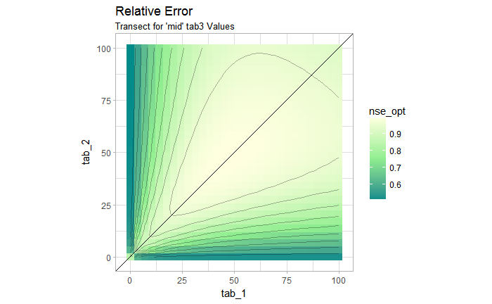

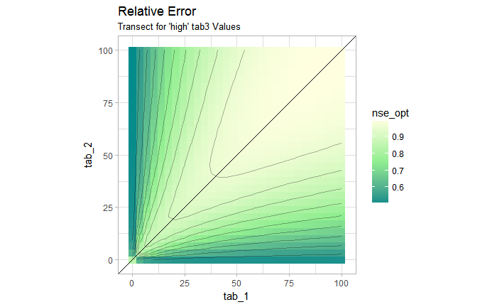

## Comparison

We can compare the first exercise with the second one by comparing their densities and see that the 2 dimensional case has more extremely results, but for the $NSE$ also larger deviations towards bad values. The 3 dimensional case has less perfect values, but also smaller deviations towards the worse performance

[output not shown]

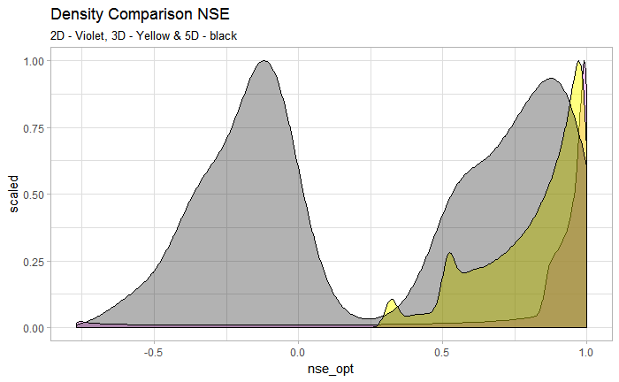

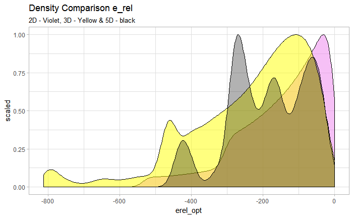

## Summary

In this section we see the same phenomenon as obtained by aggregation. Perfect approximations can be found along the 1:1 or the 1:1:1 line. Good Approximations are associated with larger $tab$ values. The approximation potential for small $tab$ is weak and strongly input dependent. Higher dimensional problems seem to have less probability to be optimizable, but also show dampened behavior if the results are not considered in a relative fashion.

# Appendix: Sketches & Co

A small test to see if the optimized “aggregation”-parameters are within the bounds of the fine scaled parameters. Here a sketch for 3 dimension:

```r
optimas_tab3_test <- optimas_tab3 %>%
  mutate(max_tab = pmax(tab_1,tab_2,tab_3),
         min_tab = pmin(tab_1,tab_2,tab_3),
         le_test = ifelse((tab_nse_opt >= min_tab & tab_nse_opt <= max_tab),1,0))


#
optimas_tab3_sub <- filter(optimas_tab3_test, tab_3 == g[20])
le_midpoint <- with(optimas_tab3_test, {mean( c(max(nse_opt),min(nse_opt)) )})
ggplot(optimas_tab3_sub) +
  geom_raster(aes(tab_1, tab_2, fill = le_test)) +
  geom_abline(color = "black") +
  labs(title = "Relative Error",
       subtitle = "Transect for 'low' tab3 Values") +
  coord_fixed( ) +
  theme_light( ) +
  theme(plot.background = element_rect(fill = '#EEEDE4'),
        legend.background = element_rect(fill = '#EEEDE4'))
```

# References

Klemes, Vit. 1982. “The Essence of Mathemtical Models of Reservoir Storage.” *Canadian Journal of Civil Engineering*. doi:10.1139/l82-072.

Szilágyi, Jósef, and András Szöllösi-Nagy. 2010. “Recursive Streamflow Forecasting: A State-Space Approach.”